# Úvod do optimalizace

MPC-OMM · přednáška 1

Tomáš Vičar

Ústav biomedicínského inženýrství · FEKT VUT

2026-09-23

## Po dnešku byste měli umět…

Rozpoznat problém

Kde se ve skutečném rozhodování skrývá optimalizace?

Sestavit model

Co jsou proměnné, účelová funkce a omezení?

Číst krajinu

Jaký je rozdíl mezi lokálním a globálním optimem?

Vysvětlit konvexitu

Proč je jednou z nejdůležitějších vlastností úlohy?

## 1 · Proč optimalizace?

> Když existuje mnoho možností, jak systematicky vybereme tu nejlepší?

## Kohoutek: když nemám model

[figure not shown]

**Mohu nastavit** dva kohoutky. **Mohu změřit** teplotu a průtok.

Chci příjemnou teplotu a dost vody, ale **neznám vztah mezi nastavením a výsledkem**.

Nastavím → změřím → porovnám → upravím.

Voda je vlažná a teče málo. Co zkusíte jako další pokus?

## Kohoutek: znalosti a měření vytvoří model

Změříme vstupní teploty: **60 °C a 10 °C**. Kalibrujeme průtoky $q_\mathrm{t},q_\mathrm{s}$ v l/min.

Z bilance vody a tepla:

$$Q=q_\mathrm{t}+q_\mathrm{s},\qquad
T=\frac{60q_\mathrm{t}+10q_\mathrm{s}}{q_\mathrm{t}+q_\mathrm{s}}.$$

Předpoklad: úplné promíchání, bez tepelných ztrát, $Q>0$.

**Model ověříme dalším měřením.**

[figure not shown]

## Stejná myšlenka v medicíně

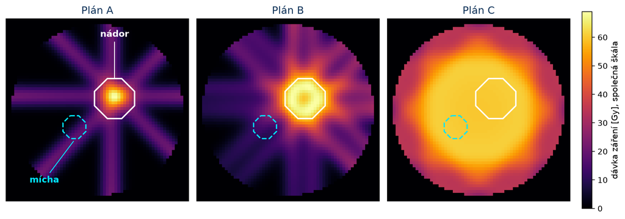

Co musí znamenat **nejlepší plán**, abychom se mohli rozhodnout?

## Od klinického cíle k nastavitelným hodnotám

[figure not shown]

Jde o didaktické schéma. Skutečné klinické plánování pracuje s mnohem podrobnější anatomií, fyzikou dávky a bezpečnostními pravidly.

## Všechno je optimalizace

Každý den

- co uvařit z toho, co je v lednici
- zabalit kufr do 23 kg
- kterou frontu u pokladny si vybrat
- rozestavět nábytek v pokoji
- rozdělit učení mezi předměty
- nastavit budík vs. stihnout autobus
- vytopit byt levně a přesto v teple

Peníze, sport, plány

- složení investičního portfolia
- pořadí splátek půjček
- tempo v maratonu, tréninkový plán
- rozvrh na semestr bez kolizí
- jízdní řády a rozvrhy směn
- rozsazení hostů na svatbě
- trasa v navigaci, rozvoz balíků

Technika a AI

- trénování neuronové sítě
- ladění hyperparametrů
- JPEG: kvalita versus velikost
- návrh filtru, antény, plošného spoje
- řízení robota a prediktivní regulace
- směrování dat v síti
- rozvrh výroby elektřiny

Medicína a technika v ní

- plánování radioterapie
- dávkování léku, inzulinová pumpa
- rekonstrukce CT a MRI, segmentace
- nastavení ventilátoru na JIP
- návrh implantátu, stentu, protézy
- rozvrh sálů, rozmístění sanitek
- práh diagnostického testu (ROC)

Příroda počítá sama

- světlo volí nejrychlejší dráhu (Fermat)
- mýdlová bublina minimalizuje povrch
- protein se skládá do minima energie
- cévy se větví podle Murrayova zákona
- chůze s nejmenší spotřebou energie
- včelí plástev: nejméně vosku
- evoluce maximalizuje zdatnost

Věda a společnost

- odhad parametrů z dat (nejmenší čtverce)
- zarovnání DNA sekvencí
- návrh experimentu a klinické studie
- očkovací strategie při málu dávek
- chemická rovnováha (minimum energie)
- rozdělení mandátů po volbách
- kde postavit sklad, školu, nabíječku

Liší se slovník, ne podstata: **co měním**, **co zlepšuji**, **co nesmím porušit**. Rozdíl je jen v tom, jak dobře to umíme zapsat a vyřešit.

## Kde optimalizaci potkáváme?

Biosignály

Odhad parametrů, odstranění šumu, detekce událostí.

Zobrazování

Rekonstrukce CT/MRI, segmentace, registrace.

Léčba

Plánování dávky, rozvrh terapie, návrh implantátu.

Bioinformatika

Výběr genů, zarovnání sekvencí, skládání proteinů.

Strojové učení

Trénování parametrů a ladění hyperparametrů.

Experimenty

Výběr měření, senzorů a informativních podmínek.

## Dva příběhy, jeden princip

### Ceres · 1801

Z několika nepřesných pozorování bylo třeba odhadnout dráhu ztracené trpasličí planety. Gaussův výpočet pomohl rozvinout **metodu nejmenších čtverců**.

$$\min_\mathbf x \; \sum_i \bigl(y_i-\hat y_i(\mathbf x)\bigr)^2$$

### Stiglerova dieta · 1945

Jak sestavit co nejlevnější jídelníček, který splní výživové požadavky? Vznikne **lineární program** s cenou jako cílem a živinami jako omezeními.

$$\min_\mathbf x \; \mathbf c^\mathsf{T}\mathbf x
\quad\text{s.t.}\quad A\mathbf x\geq\mathbf b$$

Stejný jazyk dnes používáme pro modely s miliony proměnných.

## 2 · Anatomie optimalizační úlohy

> Co můžeme měnit, čeho chceme dosáhnout a co nesmíme porušit?

## Kohoutek: co přesně znamená nejlepší?

Proměnné: $\mathbf x=(q_\mathrm{t},q_\mathrm{s})$.

Cíle: teplota **38,5 °C**, průtok **12 l/min**.

Odchylky normalizujeme; průtoku dáme váhu $\lambda>0$:

$$f(\mathbf x)=\left(\frac{T(\mathbf x)-38{,}5\,{}^\circ\mathrm C}{1\,{}^\circ\mathrm C}\right)^2
+\lambda\left(\frac{Q(\mathbf x)-12\,\mathrm{l/min}}{1\,\mathrm{l/min}}\right)^2.$$

**Menší je lepší.** Nula znamená splnění obou cílů.

Bez limitu stačí vyřešit dvě rovnice:

$$q_\mathrm{t}+q_\mathrm{s}=12,
\qquad 60q_\mathrm{t}+10q_\mathrm{s}=38{,}5\cdot12.$$

Vyjde $\mathbf x^\star=(6{,}84;\,5{,}16)$ l/min a $f(\mathbf x^\star)=0$.

**Váhu volíme my:** větší $\lambda$ více trestá chybu průtoku. Pro $\lambda=1$ mají chyby o 1 °C a 1 l/min stejnou váhu.

## Kohoutek: nejlepší bod může být zakázaný

[figure not shown]

Bojler dodá nejvýše **5 l/min**:

$$0\leq q_\mathrm{t}\leq5,\quad
0\leq q_\mathrm{s}\leq12,\quad Q\geq0{,}1.$$

Numerické řešení pro **$\lambda=1$**:

- teplá **5**, studená **4,08** l/min;
- teplota **37,54 °C**;
- průtok **9,08 l/min**;
- chyba **9,46** místo nuly.

Limit teplé vody je **aktivní**: v řešení platí rovnost.

[Reprodukovat výpočet a obrázky](https://github.com/tomasvicar/OMM-public/blob/master/prednasky/L1/kod/revize_priklady.py)

## Obecná formulace

### Stručný zápis

$$\mathbf x^\star \in \mathop{\arg\min}_{\mathbf x\in X} f(\mathbf x)$$

- $\mathbf x$ — rozhodovací proměnné (*decision variables*);
- $f(\mathbf x)$ — účelová funkce (*objective*);
- $X$ — přípustná množina (*feasible set*);
- $\mathbf x^\star$ — optimální řešení.

### Rozvinutý zápis

$$\begin{aligned}
\text{minimize}\quad & f(\mathbf x) \\
\text{subject to}\quad
& g_i(\mathbf x)\leq 0,\quad i=1,\dots,m,\\
& h_j(\mathbf x)=0,\quad j=1,\dots,p.
\end{aligned}$$

- $g_i$ — nerovnostní omezení (*inequality*);
- $h_j$ — rovnostní omezení (*equality*).

**Konvence: vždy minimalizujeme.** Maximalizaci stačí otočit znaménkem — $\max_\mathbf x u(\mathbf x)$ řešíme jako $\min_\mathbf x\,-u(\mathbf x)$: optimální $\mathbf x^\star$ je stejné, optimální hodnota má opačné znaménko.

## Minimum není totéž co minimalizátor

### Optimální hodnota

$$p^\star=\min_{\mathbf x\in X} f(\mathbf x)$$

Číslo: nejmenší dosažená hodnota účelové funkce.

### Optimální řešení

$$\mathbf x^\star\in\mathop{\arg\min}_{\mathbf x\in X}f(\mathbf x)$$

Hodnota proměnné nebo vektor, při kterém minima dosáhneme.

Může mít jedna optimální hodnota více různých minimalizátorů?

## Přípustná oblast a aktivní omezení

[figure not shown]

- **Přípustný bod** splňuje všechna omezení.
- Optimum bez omezení může být nepřípustné.
- **Aktivní omezení** platí v řešení s rovností.
- Aktivní omezení často určuje, kde se optimum zastaví.

V obrázku je aktivní omezení

$$x_1+x_2=6.$$

Kohoutek jsme opustili: tohle je **obecný příklad** dvou proměnných, na kterém je geometrie lépe vidět.

## Tvrdé požadavky, nebo preference?

### Omezení

„Toto nesmí být porušeno.“

$$D_O\mathbf x\leq \mathbf d_O^{\max}$$

Bezpečnostní mez, dostupný rozpočet, fyzikální zákon.

### Účelová funkce

„Čím méně, tím lépe.“

$$f(\mathbf x)=\text{chyba}+\lambda\cdot(\text{vedlejsi ucinek})$$

Preference a kompromisy, které lze mezi sebou vyvažovat.

Stejný požadavek lze někdy modelovat oběma způsoby — výsledky ale nemusí být stejné.

## Optimalizace je jen část rozhodovacího procesu

**1 · Realita**

Pacient, data, přístroj

→

**2 · Model**

$\mathbf x$, $f(\mathbf x)$, omezení

→

**3 · Solver**

Najde kandidáta $\mathbf x^\star$

→

**4 · Validace**

Je řešení bezpečné a užitečné?

**Důležité**

Solver může dokonale vyřešit matematickou úlohu — a přesto odpovědět na špatně položenou otázku.

## Když solver vyřeší špatně položenou úlohu

### Zadání: „co nejméně ozářit zdravou tkáň“

$$\begin{aligned}
\text{minimize}\quad & \lVert D_{\mathrm{zdrava}}\,\mathbf x\rVert^2\\
\text{subject to}\quad & \mathbf x\geq0
\end{aligned}$$

Solver vrátí $\mathbf x^\star=0$ — **ozařovač vůbec nezapneme**. Účelová funkce je nulová, řešení je matematicky optimální. Nádor ale zůstal neléčený.

### Co v modelu chybělo

$$\begin{aligned}
\text{minimize}\quad & \lVert D_{\mathrm{zdrava}}\,\mathbf x\rVert^2\\
\text{subject to}\quad & D_{\mathrm{nador}}\,\mathbf x\geq \mathbf d_{\mathrm{predpis}},\\
& \mathbf x\geq0
\end{aligned}$$

Teprve s požadavkem na účinek léčby je „co nejmenší dávka“ smysluplný cíl.

Stejná past jinde: maximalizace **senzitivity** testu vede k „všichni jsou nemocní“; minimalizace **čekací doby** oddělení k odmítání složitých pacientů; minimalizace **trénovací chyby** k přeučené síti. Solver optimalizuje to, co jsme napsali — ne to, co jsme mysleli.

## 3 · Jednoduché příklady

> Stejná anatomie se skrývá i v každodenních situacích.

## Auto: nejdřív mám jen pokusy

Neznám celou křivku spotřeby. Zvolím rychlost, provedu srovnatelnou jízdu a změřím spotřebu.

[figure not shown]

Kde měřit příště? Nejlepší **změřený bod** nemusí být nejlepší možná rychlost.

Ilustrační data pro stejný didaktický model, který si odvodíme na dalším slidu.

## Auto: sestavím a ověřím model

Znalosti navrhnou tvar, měření určí parametry:

$$f(v)=\frac{A}{v}+Bv+C.$$

- $A/v$: část spotřeby závislá na čase jízdy;
- $Bv$: jednoduché přiblížení rostoucího příspěvku;
- $C$: konstantní část.

Pro ilustrační data vyjde $A=400$, $B=0{,}05$, $C=1{,}5$.

$v$ v km/h, $f(v)$ v l/100 km.

[figure not shown]

Model je zjednodušení. Parametry odhadneme z měření a předpověď ověříme na dalších jízdách.

## Auto: model vyřeším vzorcem nebo algoritmem

**Analyticky:** ve vnitřním minimu je sklon nulový.

$$f'(v)=-\frac{400}{v^2}+0{,}05=0.$$

$$v^\star=\sqrt{8000}\approx89{,}44\ \mathrm{km/h}.$$

Protože $f''(v)=800/v^3>0$ pro $v>0$, jde o jediné minimum.

**Numericky:** algoritmus opakovaně vyhodnocuje model a zlepšuje návrh rychlosti.

Nemusíme umět vyřešit rovnici ručně. Některé algoritmy využijí sklon, jiné jen hodnoty.

Pro interval $50\leq v\leq130$ dostaneme tutéž rychlost a spotřebu **10,44 l/100 km**.

Výsledek pak ověříme **jízdou**.

## Auto: limit změní optimum

[figure not shown]

**Do 130 km/h:** optimum je uvnitř intervalu, $v^\star\approx89{,}44$ km/h; omezení nejsou aktivní.

**Do 80 km/h:** nejlepší přípustná rychlost je $v^\star=80$ km/h, spotřeba **10,50 l/100 km**. Horní mez je aktivní.

[Reprodukovat model a obrázky](https://github.com/tomasvicar/OMM-public/blob/master/prednasky/L1/kod/revize_priklady.py)

## Od derivace ke gradientu

Jedna proměnná: znaménko $f'(x)=\dfrac{\mathrm df}{\mathrm dx}$ říká, zda funkce lokálně roste, nebo klesá.

Více proměnných:

$$\nabla f(\mathbf x)=
\bigl[\partial f/\partial x_1,\;\dots,\;\partial f/\partial x_n\bigr]^\mathsf T$$

Gradient míří do směru **nejrychlejšího růstu** a je kolmý na vrstevnice; $-\nabla f(\mathbf x)$ je proto směr sestupu.

**Gradientní sestup**

$$\mathbf x_{k+1}=\mathbf x_k-\alpha\,\nabla f(\mathbf x_k)$$

$\alpha>0$ je délka kroku: malé $\alpha$ = pomalu, velké $\alpha$ = přeskočíme minimum. Podrobně ve čtvrté přednášce.

[figure not shown]

## Tři proměnné a omezení: Gin & Tonic

Rozhodujeme o objemech ginu, toniku a citronové šťávy

$$\mathbf x=(x_\text{gin},x_\text{tonic},x_\text{lemon})^\mathsf T.$$

$$\begin{aligned}
\text{minimize}\quad &-T(\mathbf x)\\
\text{subject to}\quad &\mathbf1^\mathsf T\mathbf x=V\\
&\mathbf x\geq\mathbf 0
\end{aligned}$$

Chuť $T(\mathbf x)$ chceme co největší, proto minimalizujeme $-T(\mathbf x)$; objem sklenice je tvrdé omezení a záporný objem nelze nalít.

[figure not shown]

Hodnotu $T(\mathbf x)$ získáme ochutnáním a **číselným hodnocením**. Nemáme známý vzorec ani dostupnou derivaci; měření může být šumové. Takové vyhodnocování se označuje jako *black-box*. Samotné porovnání „lepší / horší“ poskytuje ještě méně informace než číselné hodnocení.

## Kolik proměnných? Od křivky k neviditelné krajině

[figure not shown]

Intuice z 1D a 2D obrázků platí dál: gradient, vrstevnice i aktivní omezení existují v každé dimenzi — jen z intervalu a oblasti zbude seznam nerovností $g_i(\mathbf x)\leq0$. Co nefunguje, je **hledání hrubou silou**: deset hodnot na proměnnou znamená $10^n$ vyhodnocení, tedy $10^{20}$ už pro 20 proměnných.

## Má každá úloha řešení?

[figure not shown]

Než spustíme algoritmus, měli bychom se ptát: je množina přípustných řešení neprázdná a může účelová funkce svého minima dosáhnout?

## 4 · Lokální, globální a konvexní

> Jak poznáme, zda jsme našli nejlepší řešení — a ne pouze nejbližší údolí?

## Lokální versus globální minimum

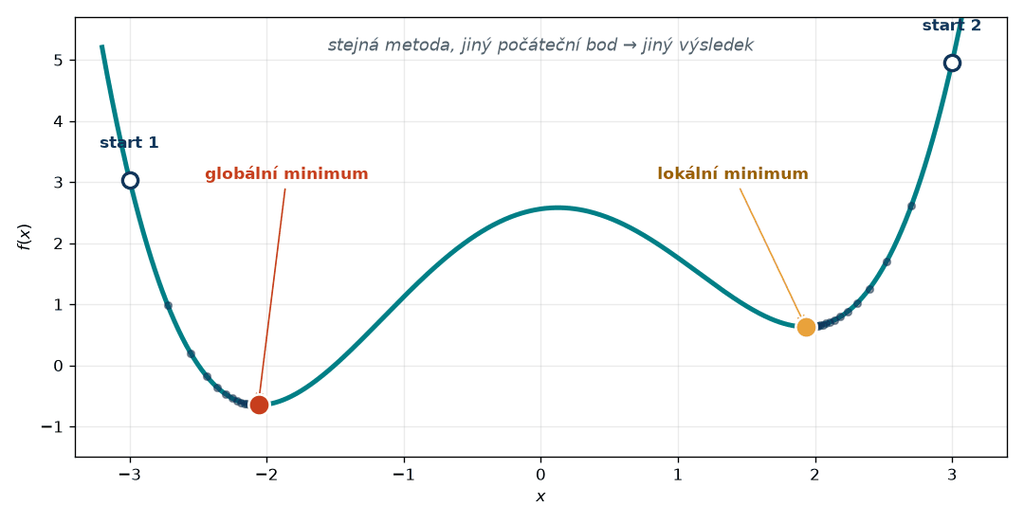

- **Lokální minimum:** nejlepší řešení v určitém okolí.
- **Globální minimum:** nejlepší řešení v celé přípustné množině.
- Lokální metoda skončí v tom údolí, do kterého ji zavede **počáteční bod** $x_0$ — a obvykle nepozná, že jinde je to lepší.

## Konvexita: množina i funkce

**Množina:** úsečka mezi každými dvěma body zůstává uvnitř.

$$\lambda\mathbf x+(1-\lambda)\mathbf y\in C$$

pro všechna $\mathbf x,\mathbf y\in C$, $\lambda\in[0,1]$.

[figure not shown]

**Funkce:** graf leží pod každou svou tětivou.

$$\begin{aligned}
f(\lambda\mathbf x+(1-\lambda)\mathbf y)\\
\leq\lambda f(\mathbf x)+(1-\lambda)f(\mathbf y)
\end{aligned}$$

pro všechna $\mathbf x,\mathbf y$ z konvexního definičního oboru, $\lambda\in[0,1]$.

[figure not shown]

## Proč na konvexitě záleží?

U konvexní optimalizační úlohy je každé lokální minimum zároveň globální.

Konvexní optimalizační úloha má:

- konvexní účelovou funkci;
- konvexní přípustnou množinu;
- v běžném standardním tvaru konvexní nerovnosti a afinní rovnosti.

Proto existují obecné algoritmy, které velké konvexní úlohy řeší spolehlivě a často velmi rychle.

## Co konvexita sama nezaručuje

Existenci

Například $\min_{x\in\mathbb R} e^x$ má infimum $0$, ale žádné konečné $x$ ho nedosáhne.

Jednoznačnost

Konstantní nebo plochá část konvexní funkce může mít více minimalizátorů.

Dobrý model

Matematická řešitelnost neříká, zda účel a omezení správně vystihují realitu.

Klinickou platnost

Výsledek stále vyžaduje kontrolu dat, předpokladů a bezpečnosti.

## 5 · Mapa optimalizačních problémů

> Nejprve poznáme strukturu úlohy, potom volíme metodu.

## Vlastnost problému ≠ vlastnost metody

### Jaký je problém?

- spojité, nebo diskrétní proměnné;
- lineární, kvadratický, nebo obecně nelineární model;
- konvexní, nebo nekonvexní;
- deterministická data, nebo nejistota.

### Jak jej řešíme?

- analyticky, nebo numericky;
- gradientní, nebo bezderivační metodou;
- deterministicky, nebo stochasticky;
- přesným solverem, nebo heuristikou.

Struktura problému omezuje vhodné metody. Dobře řešitelná konvexní formulace bývá přirozenou první volbou.

## Základní třídy — zatím jen orientačně

LP

Lineární účel i omezení.

$\min\ \mathbf c^{\mathsf T}\mathbf x,\quad A\mathbf x\leq\mathbf b$

QP

Kvadratický účel, lineární omezení.

$\min\ \tfrac12\mathbf x^{\mathsf T}Q\mathbf x+\mathbf c^{\mathsf T}\mathbf x$

NLP

Obecná nelineární funkce nebo omezení.

$\min\ f(\mathbf x)$

IP / MIP

Některé nebo všechny proměnné jsou celočíselné.

$x_i\in\mathbb Z$

Názvy dnes stačí **slyšet**; přesné formulace přijdou v dalších přednáškách.

## Stejná třída, různé aplikace

| Třída | Kde se objevuje | Typické rozhodnutí |
| --- | --- | --- |
| LP | výživa pacienta a Stiglerova dieta rozvrh personálu, rozdělení rozpočtu směšování roztoků | kolik čeho, při lineárních mezích |
| Konvexní QP | plánování radioterapie nejmenší čtverce s regularizací prediktivní řízení dávkovače | spojité nastavení s kvadratickou cenou |
| Konvexní model | rekonstrukce CT/MRI komprimované snímání, odšumění logistická regrese | obraz či model odpovídající měřením |
| Nekonvexní model | registrace obrazů trénování neuronové sítě slepá dekonvoluce | transformace obrazu nebo váhy modelu |
| Celočíselná úloha | výběr senzorů či biomarkerů rozvrh operačních sálů plánování svozu vzorků | co a kdy vůbec použít |
| Black-box úloha | volba dalšího experimentu ladění hyperparametrů návrh měřicího protokolu | kde provést další drahé vyhodnocení |

Konvexní formulace dávají silné záruky; nekonvexita, celočíselnost a drahá vyhodnocení hledání komplikují. Nejde o úplné pořadí obtížnosti.

## Kam povede celý předmět

[figure not shown]

Deset výukových přednášek podle aktuálního harmonogramu 2026/27. 28. října výuka odpadá; 9. prosince jsou volitelné konzultace.

## Příště: lineární programování

Vrátíme se ke Stiglerově dietě v modernější podobě:

$$\begin{aligned}
\text{minimize}\quad & \mathbf c^\mathsf T\mathbf x\\
\text{subject to}\quad & A\mathbf x\geq\mathbf b\\
& \mathbf x\geq0
\end{aligned}$$

Budeme řešit:

- jak takovou úlohu poznat a zapsat;
- jak vypadá přípustná oblast;
- proč optimum hledáme ve vrcholech;
- jak funguje simplex a co znamená dualita.

## Ochutnávka LP: co dnes péct?

Pekárna má denně **80 kg mouky** a **600 minut pece**. Chléb vynese 14 Kč (0,5 kg mouky, 3 min pece), bageta 8 Kč (0,2 kg mouky, 2 min pece). Kolik čeho upéct?

$$\begin{aligned}
\text{maximize}\quad & 14x_1+8x_2 && \text{zisk}\\
\text{subject to}\quad & 0{,}5x_1+0{,}2x_2\leq80 && \text{mouka}\\
& 3x_1+2x_2\leq600 && \text{pec}\\
& x_1,x_2\geq0
\end{aligned}$$

Optimum $\mathbf x^\star=(100,150)$ se ziskem 2600 Kč: obě suroviny padnou beze zbytku, obě omezení jsou **aktivní**.

[figure not shown]

Maximalizaci zapíšeme ve standardním tvaru jako $\min\,-14x_1-8x_2$. U této úlohy lze optimum nalézt ve **vrcholu** neprázdného omezeného mnohoúhelníku. Na pohybu mezi vrcholy staví simplexová metoda z příští přednášky.

## Od tabulky k maticím a k solveru

$$\begin{aligned}
\text{maximize}\quad & \color{#c73e1d}{14}x_1+\color{#c73e1d}{8}x_2\\
\text{subject to}\quad & \color{#007f86}{0{,}5}x_1+\color{#007f86}{0{,}2}x_2\leq\color{#9a6200}{80}\\
& \color{#007f86}{3}x_1+\color{#007f86}{2}x_2\leq\color{#9a6200}{600}\\
& x_1,x_2\geq0
\end{aligned}$$

↓ koeficienty přepíšeme do vektorů a matice ↓

$$\mathbf c=\begin{bmatrix}\color{#c73e1d}{14}\\\color{#c73e1d}{8}\end{bmatrix},\;
A=\begin{bmatrix}\color{#007f86}{0{,}5}&\color{#007f86}{0{,}2}\\\color{#007f86}{3}&\color{#007f86}{2}\end{bmatrix},\;
\mathbf b=\begin{bmatrix}\color{#9a6200}{80}\\\color{#9a6200}{600}\end{bmatrix}$$

$$\begin{aligned}
\text{maximize}\quad & \mathbf c^\mathsf T\mathbf x\\
\text{subject to}\quad & A\mathbf x\leq\mathbf b,\quad \mathbf x\geq0
\end{aligned}$$

Řádek $A$ = surovina, sloupec = výrobek. Ve standardním tvaru $\min\,-\mathbf c^\mathsf T\mathbf x$; stejný tvar má i Stiglerova dieta, jen s většími maticemi.

```python
import cvxpy as cp
import numpy as np

c = np.array([14.0, 8.0])            # zisk za kus
A = np.array([[0.5, 0.2],            # mouka
              [3.0, 2.0]])           # pec
b = np.array([80.0, 600.0])

x = cp.Variable(2, nonneg=True)
uloha = cp.Problem(cp.Maximize(c @ x), [A @ x <= b])
uloha.solve()
```

```
x* = [100. 150.]   zisk = 2600 Kč
A x* = [ 80. 600.]  → obě omezení aktivní
stínové ceny = [10.  3.]
```

Kilogram mouky navíc přinese 10 Kč, minuta pece 3 Kč.

[Zdroj ukázky na GitHubu](https://github.com/tomasvicar/OMM-public/blob/master/prednasky/L1/kod/lp_pekarna_cvxpy.py)

## Co si odnést

1. Optimalizace mění **možnosti a požadavky** na matematický model rozhodnutí.
2. Každá úloha potřebuje **proměnné, účelovou funkci a omezení**.
3. Lokální optimum nemusí být globální; u konvexní úlohy tento problém mizí.
4. Ne každá formulace má řešení a ne každé matematické řešení dává smysl v realitě.
5. Struktura problému rozhoduje, jakou metodu má smysl použít.

Dokážete u nového problému říct: **co měním, co zlepšuji a co nesmím porušit?**

## Rychlá kontrola

1. Jaký je rozdíl mezi $\min f(\mathbf x)$ a $\arg\min f(\mathbf x)$?
2. Co znamená, že je omezení v optimu aktivní?
3. Proč je konvexita pro optimalizaci tak užitečná?
4. Proč stačí umět minimalizovat, i když chceme něco maximalizovat?
5. Co se pokazí, když má úloha místo dvou proměnných dva miliony?

## Zdroje a reprodukovatelný kód

Inspirace pro strukturu a příklady:

- S. Boyd, L. Vandenberghe: *Convex Optimization*;
- J. Pfrommer: *Optimization Methods for Machine Learning and Engineering*;
- S. L. Brunton: *Optimization: A Bootcamp for Machine Learning, Inverse Problems, and Control*.

Zdrojové soubory:

- [generátor obrázků](https://github.com/tomasvicar/OMM-public/blob/master/prednasky/L1/kod/generuj_obrazky.py);
- [evidence převzatých ilustrací](https://github.com/tomasvicar/OMM-public/blob/master/prednasky/L1/zdroje.md).

## Dodatek · Matematika, ke které se vracíme

> Zápis, vektory, matice a derivace potřebné pro první tři přednášky.

**Materiál k samostudiu a opakování.** Hlavní výklad končí před dodatkem; sem se vracejte, když v příkladu narazíte na neznámý symbol.

## Skalár, vektor, matice: co právě držím?

| Zápis | Význam | Pekárna |
| --- | --- | --- |
| $x_1\in\mathbb R$ | skalár: jedno reálné číslo | počet chlebů |
| $\mathbf x=\begin{bmatrix}x_1\\x_2\end{bmatrix}\in\mathbb R^2$ | sloupcový vektor: uspořádaný seznam | počty chlebů a baget |
| $A\in\mathbb R^{2\times2}$ | matice: tabulka, řádky × sloupce | spotřeba dvou zdrojů na dva výrobky |
| $A_{ij}$ | položka v řádku $i$, sloupci $j$ | $A_{12}=0{,}2$: mouka na bagetu |
| $\mathbf x^\mathsf T$ | transpozice: ze sloupce řádek | $[x_1\;x_2]$, rozměr $1\times2$ |
| $\sum_{i=1}^n a_i$ | součet $a_1+\cdots+a_n$ | sečtení příspěvků jednotlivých výrobků |

Vektor má **pořadí a význam složek**. Hodnoty $[100,150]^\mathsf T$ a $[150,100]^\mathsf T$ jsou dva různé výrobní plány.

## Skalární součin a normy: součet versus délka

### Skalární součin dává jedno číslo

Pro $\mathbf c,\mathbf x\in\mathbb R^n$:

$$\mathbf c^\mathsf T\mathbf x=\sum_{i=1}^{n}c_ix_i.$$

Zisk pekárny: $14\cdot100+8\cdot150=2600$. Každou složku násobíme její **vahou** a sečteme.

### Obecná norma Lₚ

$$\|\mathbf x\|_p=\left(\sum_{i=1}^{n}|x_i|^p\right)^{1/p},
\qquad 1\leq p<\infty.$$

Pro $0<p<1$ tento výraz obecně **není normou**.

Vzdálenost bodů v normě Lₚ: $\|\mathbf x-\mathbf y\|_p$.

### Norma měří velikost vektoru

$$\begin{aligned}
\|\mathbf x\|_1&=\sum_{i=1}^{n}|x_i|,\\[0.3em]
\|\mathbf x\|_2&=\sqrt{\sum_{i=1}^{n}x_i^2},\\[0.3em]
\|\mathbf x\|_\infty&=\max_{1\leq i\leq n}|x_i|
=\lim_{p\to\infty}\|\mathbf x\|_p.
\end{aligned}$$

Pro $\mathbf d=(3,4)^\mathsf T$: $\|\mathbf d\|_1=7$, $\|\mathbf d\|_2=5$, $\|\mathbf d\|_\infty=4$.

[figure not shown]

## Maticový součin: všechny spotřeby najednou

$$\underbrace{\begin{bmatrix}0{,}5&0{,}2\\3&2\end{bmatrix}}_{A:\,2\times2}
\underbrace{\begin{bmatrix}100\\150\end{bmatrix}}_{\mathbf x:\,2\times1}
=
\underbrace{\begin{bmatrix}0{,}5\cdot100+0{,}2\cdot150\\3\cdot100+2\cdot150\end{bmatrix}}_{A\mathbf x:\,2\times1}
=\begin{bmatrix}80\\600\end{bmatrix}.$$

- Řádek matice = jeden **zdroj**.
- Sloupec matice = jeden **výrobek**.
- Výsledek = spotřeba **80 kg mouky** a **600 minut pece**.
- $A\mathbf x\leq\mathbf b$ znamená nerovnost **po složkách**.

Obecné pravidlo rozměrů:

$$(m\times n)(n\times1)=(m\times1).$$

```python
spotreba = A @ x
pripustny = (spotreba <= b).all()
```

`@` násobí matice; `*` v NumPy násobí po složkách.

## Lineární a afinní: přímka nemusí být lineární

[figure not shown]

**Lineární:** $f(\mathbf x)=\mathbf c^\mathsf T\mathbf x$.

$$f(a\mathbf x+b\mathbf y)=af(\mathbf x)+bf(\mathbf y).$$

Platí zejména $f(\mathbf0)=0$.

**Afinní:** $f(\mathbf x)=\mathbf c^\mathsf T\mathbf x+d$.

Lineární část plus konstantní posun. Omezení $A\mathbf x=\mathbf b$ jsou **afinní rovnosti**.

## Derivace: místní citlivost na změnu

[figure not shown]

$$f'(x)=\lim_{h\to0}\frac{f(x+h)-f(x)}{h}.$$

Derivace je **směrnice tečny**.

$$f(x+h)\approx f(x)+f'(x)h.$$

Pro $f(x)=(x-2)^2$:

$$f'(x)=2(x-2),\qquad f'(1)=-2.$$

V okolí jedničky funkci snižujeme **zvětšováním** $x$.

## Pravidla derivování: rozložte výpočet na kroky

| Funkce | Derivace |
| --- | --- |
| konstanta $c$ | $0$ |
| $x^k$ | $kx^{k-1}$ |
| $e^x$ | $e^x$ |
| $\ln x$, $x>0$ | $1/x$ |
| $af+bg$ | $af'+bg'$ |
| $fg$ | $f'g+fg'$ |
| $f(g(x))$ | $f'(g(x))g'(x)$ |

### Řetězové pravidlo

$$f(x)=(2x-3)^2
\quad\Rightarrow\quad f'(x)=2(2x-3)\cdot2.$$

Vnější čtverec × derivace vnitřního výrazu.

### Model spotřeby auta

$$\begin{aligned}
s(v)&=400v^{-1}+0{,}05v+1{,}5,\\
s'(v)&=-400v^{-2}+0{,}05.
\end{aligned}$$

Na $v>0$ vychází $s'(v)=0$ při $v=\sqrt{8000}$.

## Parciální derivace a gradient: více knoflíků

$$f(\mathbf x)=(x_1-1)^2+2x_2^2.$$

Derivujeme podle jedné proměnné; **ostatní držíme pevné**.

$$\nabla f(\mathbf x)=
\begin{bmatrix}\partial f/\partial x_1\\\partial f/\partial x_2\end{bmatrix}
=\begin{bmatrix}2(x_1-1)\\4x_2\end{bmatrix}.$$

V bodě $\mathbf x=(0,1)^\mathsf T$:

$$\nabla f(\mathbf x)=(-2,4)^\mathsf T.$$

Krok $\mathbf x-0{,}25\nabla f(\mathbf x)=(0{,}5,0)^\mathsf T$ sníží hodnotu **z 3 na 0,25**.

[figure not shown]

## Křivost: nulová derivace ještě není minimum

[figure not shown]

V jednom rozměru, pokud $f'(x^\star)=0$:

- $f''(x^\star)>0$: ostré lokální minimum;
- $f''(x^\star)<0$: ostré lokální maximum;
- $f''(x^\star)=0$: test nerozhodne.

Ve více rozměrech sestavíme **Hessián**:

$$H_{ij}(\mathbf x)=\frac{\partial^2 f}{\partial x_i\partial x_j}.$$

Křivost ve směru $\mathbf d$ měří kvadratická forma $\mathbf d^\mathsf TH\mathbf d$.

## Exponenciála, logaritmus a definiční obor

[figure not shown]

- $e^x>0$ pro všechna reálná $x$.
- $\ln x$ je definovaný pouze pro $x>0$.
- $\ln(ab)=\ln a+\ln b$ pro $a,b>0$.
- Rostoucí logaritmus zachová **místo maxima** kladné funkce.

Didaktický model ze cvičení, $0\leq H\leq1$:

$$D(H)=He^{-2{,}5H}.$$

Pro $H>0$: $\ln D(H)=\ln H-2{,}5H$.

$$(\ln D)'=\frac1H-2{,}5=0
\quad\Rightarrow\quad H^\star=0{,}4.$$

## Dodatek: zkuste to bez nápovědy

1. Jaký rozměr má $A\mathbf x$, když $A\in\mathbb R^{3\times2}$ a $\mathbf x\in\mathbb R^2$?
2. Pro $\mathbf c=(14,8)^\mathsf T$ a $\mathbf x=(100,150)^\mathsf T$ spočítejte $\mathbf c^\mathsf T\mathbf x$. Co výsledek znamená?
3. Je $f(x)=3x+2$ lineární, afinní, nebo ani jedno?
4. Jaká je derivace $(2x-3)^2$ v bodě $x=1$?
5. Jaký je gradient $(x_1-1)^2+2x_2^2$ v bodě $(0,1)^\mathsf T$?
6. Proč nelze do $\ln H-2{,}5H$ dosadit $H=0$? Zmizel tím tento bod i z původní úlohy?

## Dodatek: odpovědi a další návrat ke kódu

1. Sloupcový vektor délky **3**: $(3\times2)(2\times1)=(3\times1)$.
2. **2600 Kč**, celkový zisk tohoto výrobního plánu.
3. **Afinní**, v přesném matematickém významu není lineární: $f(0)=2\ne0$.
4. $f'(x)=4(2x-3)$, tedy **$f'(1)=-4$**.
5. **$\nabla f(0,1)=(-2,4)^\mathsf T$**. Malý krok opačným směrem snižuje funkci.
6. Logaritmus vyžaduje **kladný argument**. V původní úloze $H=0$ zůstává; zkontrolujeme ho zvlášť, protože $D(0)=0$.

[Generátor obrázků a ověření čísel dodatku](https://github.com/tomasvicar/OMM-public/blob/master/prednasky/L1/kod/revize_matematika.py)

[Spustitelný model pekárny](https://github.com/tomasvicar/OMM-public/blob/master/prednasky/L1/kod/lp_pekarna_cvxpy.py)